# Tubes_Statistik

Kaenova Mahendra Auditama<sup>1</sup>  
Rachdian Habi Yahya<sup>2</sup>  
Fendi Irfan Amorokhman<sup>3</sup>  
Arya Pangestu<sup>4</sup>  
<sup>1</sup>kaenova@student.telkomuniversity.ac.id  
<sup>2</sup>rhabiy@student.telkomuniversity.ac.id  
<sup>3</sup>fendiirfan@student.telkomuniversity.ac.id  
<sup>4</sup>aryapangestu@student.telkomuniversity.ac.id  
CII1C2-IF-43-GAB05  
Informatics Engineering, Telkom University, Indonesia  
2020

## Research Question, Method, and Prediction

### 1. Research Question

Orang yang seperti apa bank harus arahkan untuk menaikkan utilisasi kredit yang lebih tinggi? Mengapa orang-orang tersebut tidak mengutilisasikan kredit tersebut?

### 2. Method

Method yang akan digunakan adalah Statistika Deskriptif, dimana kita akan mengolah data yang sudah diberikan sehingga dapat memberikan informasi yang baru

### 3. Prediction

Menurut saya, kita akan membutuhkan data ciri-ciri orang-orang tersebut. Sehingga dapat terlihat pola yang ada dengan metode-metode statistika. Prediksi saya orang-orang yang tidak mengutilisasikan kredit tersebut merupakan orang-orang yang dari data memiliki Income yang kurang.

### Installing Packages and Load Packages

```r
install.packages("summarytools", repos = "https://repo.bppt.go.id/cran/")
install.packages("dplyr", repos = "https://repo.bppt.go.id/cran/")
install.packages("repr", repos = "https://repo.bppt.go.id/cran/")
require("summarytools")
require("dplyr")
require("repr")
```

### Importing Data Frame

```r
df <- read.csv("./BankChurners.csv")
head(df)
```

A data.frame: 6 × 23

|  | CLIENTNUM <int> | Attrition_Flag <chr> | Customer_Age <int> | Gender <chr> | Dependent_count <int> | Education_Level <chr> | Marital_Status <chr> | Income_Category <chr> | Card_Category <chr> | Months_on_book <int> | ... | Credit_Limit <dbl> | Total_Revolving_Bal <int> | Avg_Open_To_Buy <dbl> | Total_Amt_Chng_Q4_Q1 <dbl> | Total_Trans_Amt <int> | Total_Trans_Ct <int> | Total_Ct_Chng_Q4_Q1 <dbl> | Avg_Utilization_Ratio <dbl> | Naive_Bayes_Classifier_Attrition_Flag_Card_Category_Contacts_Count_12_mon_Dependent_count_Education_Level_Months_Inactive_12_mon_1 <dbl> | Naive_Bayes_Classifier_Attrition_Flag_Card_Category_Contacts_Count_12_mon_Dependent_count_Education_Level_Months_Inactive_12_mon_2 <dbl> |
| --- | --- | --- | --- | --- | --- | --- | --- | --- | --- | --- | --- | --- | --- | --- | --- | --- | --- | --- | --- | --- | --- |
| 1 | 768805383 | Existing Customer | 45 | M | 3 | High School | Married | $60K - $80K | Blue | 39 | ... | 12691 | 777 | 11914 | 1.335 | 1144 | 42 | 1.625 | 0.061 | 9.3448e-05 | 0.99991 |
| 2 | 818770008 | Existing Customer | 49 | F | 5 | Graduate | Single | Less than $40K | Blue | 44 | ... | 8256 | 864 | 7392 | 1.541 | 1291 | 33 | 3.714 | 0.105 | 5.6861e-05 | 0.99994 |
| 3 | 713982108 | Existing Customer | 51 | M | 3 | Graduate | Married | $80K - $120K | Blue | 36 | ... | 3418 | 0 | 3418 | 2.594 | 1887 | 20 | 2.333 | 0.000 | 2.1081e-05 | 0.99998 |
| 4 | 769911858 | Existing Customer | 40 | F | 4 | High School | Unknown | Less than $40K | Blue | 34 | ... | 3313 | 2517 | 796 | 1.405 | 1171 | 20 | 2.333 | 0.760 | 1.3366e-04 | 0.99987 |
| 5 | 709106358 | Existing Customer | 40 | M | 3 | Uneducated | Married | $60K - $80K | Blue | 21 | ... | 4716 | 0 | 4716 | 2.175 | 816 | 28 | 2.500 | 0.000 | 2.1676e-05 | 0.99998 |
| 6 | 713061558 | Existing Customer | 44 | M | 2 | Graduate | Married | $40K - $60K | Blue | 36 | ... | 4010 | 1247 | 2763 | 1.376 | 1088 | 24 | 0.846 | 0.311 | 5.5077e-05 | 0.99994 |

### Data Wrangling

Kita hanya akan menggunakan data Customer_Age, Gender, Card Category, Education Level, Martial Status, Income Category, Credit Limit, Total_Trans_Amt, Total_Trans_Ct, dan Avg_Utilization Ratio.

```r
#Memindahkan ke dataframe baru
wr <- data.frame("Umur_Pengguna" = df$Customer_Age,
                 "Jenis_Kelamin" = df$Gender,
                 "Jenis_Kartu" = df$Card_Category,
                 "Tingkat_Pendidikan" = df$Education_Level,
                 "Status_Pernikahan" = df$Marital_Status,
                 "Penghasilan" = df$Income_Category,
                 "Limit_Kredit" = df$Credit_Limit,
                 "Besar_Transaksi" = df$Total_Trans_Amt,
                 "Banyak_Transaksi" = df$Total_Trans_Ct,
                 "Utilisasi" = df$Avg_Utilization_Ratio)

head(wr)
```

A data.frame: 6 × 10

|  | Umur_Pengguna <int> | Jenis_Kelamin <chr> | Jenis_Kartu <chr> | Tingkat_Pendidikan <chr> | Status_Pernikahan <chr> | Penghasilan <chr> | Limit_Kredit <dbl> | Besar_Transaksi <int> | Banyak_Transaksi <int> | Utilisasi <dbl> |
| --- | --- | --- | --- | --- | --- | --- | --- | --- | --- | --- |
| 1 | 45 | M | Blue | High School | Married | $60K - $80K | 12691 | 1144 | 42 | 0.061 |
| 2 | 49 | F | Blue | Graduate | Single | Less than $40K | 8256 | 1291 | 33 | 0.105 |
| 3 | 51 | M | Blue | Graduate | Married | $80K - $120K | 3418 | 1887 | 20 | 0.000 |
| 4 | 40 | F | Blue | High School | Unknown | Less than $40K | 3313 | 1171 | 20 | 0.760 |
| 5 | 40 | M | Blue | Uneducated | Married | $60K - $80K | 4716 | 816 | 28 | 0.000 |
| 6 | 44 | M | Blue | Graduate | Married | $40K - $60K | 4010 | 1088 | 24 | 0.311 |

### Data Exploration

Pertama, kita harus tahu keterhubungan antara jenis kartu yang dipakai dan utilisasi kartu tersebut

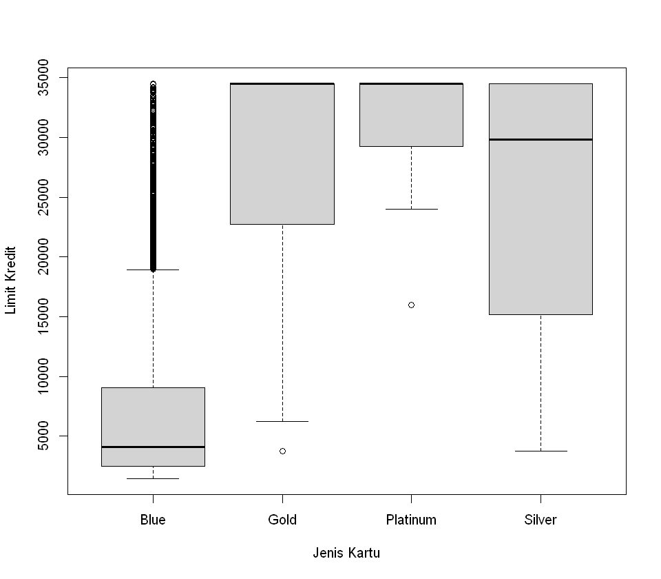

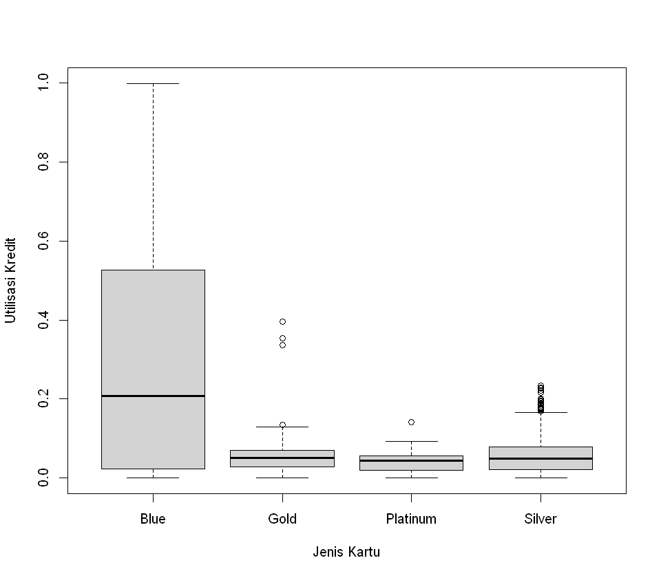

```r
options(repr.plot.width = 8, repr.plot.height =7)
plot(factor(wr$Jenis_Kartu), wr$Limit_Kredit,
    xlab = "Jenis Kartu",
    ylab = "Limit Kredit")

plot(factor(wr$Jenis_Kartu), wr$Utilisasi,
    xlab = "Jenis Kartu",
    ylab = "Utilisasi Kredit")
```

Dari hasil boxplot diatas, kita bisa melihat bahwa adanya perbedaan yang signifikan dari kartu kredit berjenis Blue yang bisa dibilang paling rendah dan dengan utilisasi tertinggi. Yang artinya pengguna yang tidak mengutilisasi kartu kredit tersebut merupakan kartu Gold Platnium dan Silver. Maka kita akan mencoba mencari tahu di daerah Pengguna yang memakai dengan jenis kartu Gold, Platinum, Silver

```r
wr <- wr[!(wr$Jenis_Kartu == "Blue"), ]
head(wr)
descr(wr)
```

A data.frame: 6 × 10

|  | Umur_Pengguna <int> | Jenis_Kelamin <chr> | Jenis_Kartu <chr> | Tingkat_Pendidikan <chr> | Status_Pernikahan <chr> | Penghasilan <chr> | Limit_Kredit <dbl> | Besar_Transaksi <int> | Banyak_Transaksi <int> | Utilisasi <dbl> |
| --- | --- | --- | --- | --- | --- | --- | --- | --- | --- | --- |
| 7 | 51 | M | Gold | Unknown | Married | $120K + | 34516 | 1330 | 31 | 0.066 |
| 8 | 32 | M | Silver | High School | Unknown | $60K - $80K | 29081 | 1538 | 36 | 0.048 |
| 38 | 42 | F | Gold | High School | Married | Less than $40K | 15433 | 966 | 22 | 0.000 |
| 43 | 50 | F | Silver | College | Single | $40K - $60K | 17304 | 1756 | 33 | 0.145 |
| 62 | 48 | M | Silver | Graduate | Married | $60K - $80K | 34516 | 691 | 15 | 0.000 |
| 66 | 51 | M | Silver | Uneducated | Single | $80K - $120K | 34516 | 1293 | 32 | 0.044 |

A summarytools: 15 × 5 of type dbl

|  | Banyak_Transaksi | Besar_Transaksi | Limit_Kredit | Umur_Pengguna | Utilisasi |
| --- | --- | --- | --- | --- | --- |
| Mean | 76.19971056 | 6.844058e+03 | 2.594959e+04 | 45.69175109 | 0.05687988 |
| Std.Dev | 27.20231341 | 4.825180e+03 | 9.534844e+03 | 7.22348655 | 0.05211891 |
| Min | 13.00000000 | 6.910000e+02 | 3.735000e+03 | 26.00000000 | 0.00000000 |
| Q1 | 58.00000000 | 3.145000e+03 | 1.592800e+04 | 41.00000000 | 0.02300000 |
| Median | 74.00000000 | 4.660000e+03 | 3.171800e+04 | 46.00000000 | 0.04900000 |
| Q3 | 98.00000000 | 9.105000e+03 | 3.451600e+04 | 50.00000000 | 0.07300000 |
| Max | 134.00000000 | 1.762800e+04 | 3.451600e+04 | 65.00000000 | 0.39500000 |
| MAD | 29.65200000 | 4.440387e+03 | 4.148315e+03 | 7.41300000 | 0.03706500 |
| IQR | 40.00000000 | 5.936500e+03 | 1.858250e+04 | 9.00000000 | 0.05000000 |
| CV | 0.35698710 | 7.050174e-01 | 3.674372e-01 | 0.15809170 | 0.91629782 |
| Skewness | -0.01826603 | 6.785742e-01 | -4.748277e-01 | -0.01587576 | 1.67668288 |
| SE.Skewness | 0.09298155 | 9.298155e-02 | 9.298155e-02 | 0.09298155 | 0.09298155 |
| Kurtosis | -0.75036792 | -9.275347e-01 | -1.485500e+00 | 0.06764243 | 5.24134567 |
| N.Valid | 691.00000000 | 6.910000e+02 | 6.910000e+02 | 691.00000000 | 691.00000000 |
| Pct.Valid | 100.00000000 | 1.000000e+02 | 1.000000e+02 | 100.00000000 | 100.00000000 |

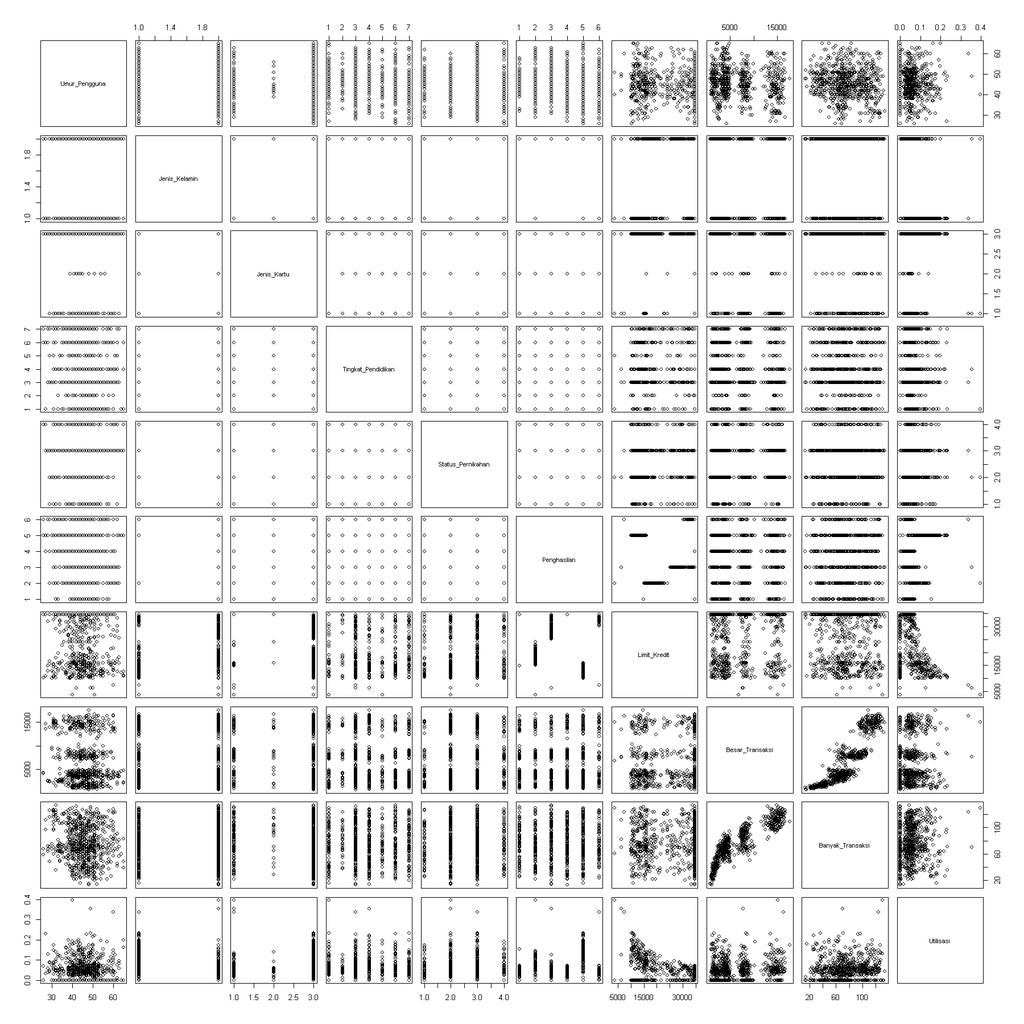

```r
options(repr.plot.width = 15, repr.plot.height = 15)
plot(wr, cex.lab = 15)
```

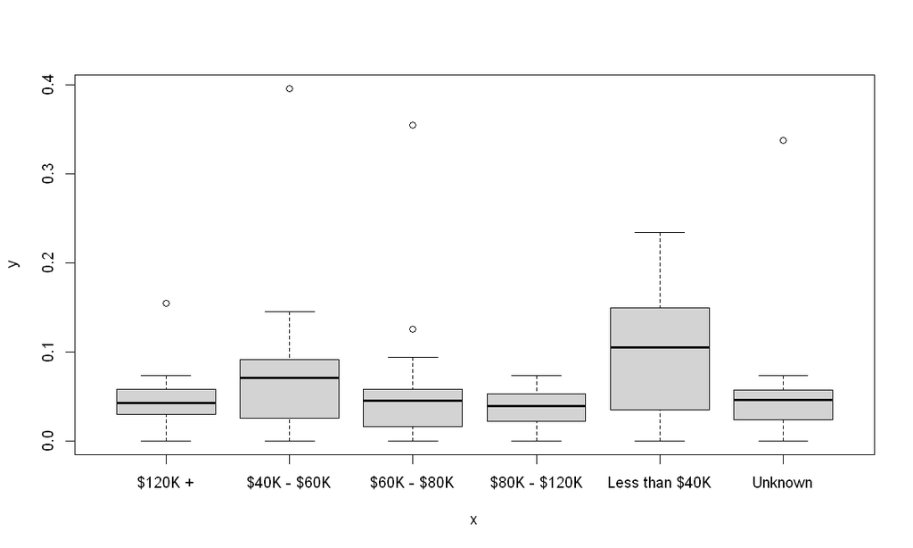

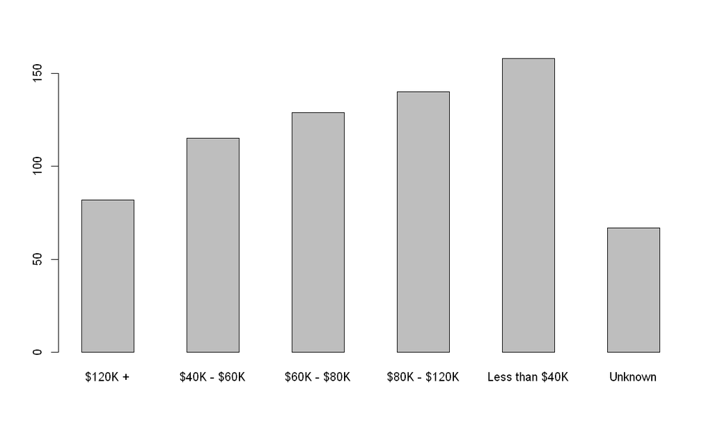

```r
options(repr.plot.width = 10, repr.plot.height = 6)
plot(factor(wr$Penghasilan), wr$Utilisasi)
barplot(table(wr$Penghasilan), space = TRUE)
```